# house_prices_predict

**大作业要求**

一、自选数据集，完成一次（数据分析+挖掘的综合实验）。要求：

1、数据分析必须包含数据预处理、索引查询、分类分组汇总

2、数据挖掘，需包含数据预处理（异常值、缺失值、标准化等）中的一个功能 + 一个挖掘模型

3、用图表呈现分析结果

4、用文字总结最终的分析结果

二、数据来源（选择下面之一）：

1、采用与自己学业有关的数据。

2、联合国网站（[https://population.un.org/wpp/Download/Standard/MostUsed/）](https://population.un.org/wpp/Download/Standard/MostUsed/%EF%BC%89)

3、机器学习数据集网站选择下载（ [https://www.kaggle.com），注册需要安装些插件](https://www.kaggle.com%EF%BC%89%EF%BC%8C%E6%B3%A8%E5%86%8C%E9%9C%80%E8%A6%81%E5%AE%89%E8%A3%85%E4%BA%9B%E6%8F%92%E4%BB%B6)

4、sklearn的数据集

5、金融数据，基本要收费 https://tushare.pro/

# Kaggle：房价预测

```python
%matplotlib inline
import numpy as np
import pandas as pd
import torch
from torch import nn
import matplotlib.pyplot as plt
from d2l import torch as d2l
from torch.utils.data import DataLoader, TensorDataset
```

## 0. 选择数据集

Kaggle的房价预测数据集由Bart de Cock于2011年收集 (De Cock, 2011)， 涵盖了2006-2010年期间亚利桑那州埃姆斯市的房价。

```python
train_data = pd.read_csv("house-price-data/train.csv")
test_data = pd.read_csv("house-price-data/test.csv")
```

其中train_data是训练集，包含79个特征和1个标签（房价）。test_data中只包含79个特征，不含标签，是测试我们模型准确性和泛化能力的对象。

训练时我们将实用`all_features`作为特征数据集。

## 1. 索引查询

对原始数据`train_data`做索引查询

1. 查询特定行或列
   - 查询特定列
   - 查询多列
2. 多条件查询
   - 查询LotArea大于10000且SalePrice大于200000的房屋
   - 查询YearBuilt在2000年之后的房屋
3. 按索引位置查询
   - 查询前10行数据
   - 查询特定位置的数据，如第5行第3列
4. 按标签查询
   - 查询Id为1的数据
   - 查询Id为1和2的数据

### 1.1 查询特定行或列

```python
# 查询特定列
train_data["1stFlrSF"].head()
```

```
0     856
1    1262
2     920
3     961
4    1145
Name: 1stFlrSF, dtype: int64
```

```python
# 查询多列
train_data[["Utilities", "1stFlrSF"]].head()
```

|  | Utilities | 1stFlrSF |
| --- | --- | --- |
| 0 | AllPub | 856 |
| 1 | AllPub | 1262 |
| 2 | AllPub | 920 |
| 3 | AllPub | 961 |
| 4 | AllPub | 1145 |

### 1.2 多条件查询

```python
# 多条件查询
# 查询LotArea大于10000且SalePrice大于200000的房屋
train_data[(train_data['LotArea'] > 10000) & (train_data['SalePrice'] > 200000)].head()
```

|  | Id | MSSubClass | MSZoning | LotFrontage | LotArea | Street | Alley | LotShape | LandContour | Utilities | ... | PoolArea | PoolQC | Fence | MiscFeature | MiscVal | MoSold | YrSold | SaleType | SaleCondition | SalePrice |
| --- | --- | --- | --- | --- | --- | --- | --- | --- | --- | --- | --- | --- | --- | --- | --- | --- | --- | --- | --- | --- | --- |
| 2 | 3 | 60 | RL | 68.0 | 11250 | Pave | NaN | IR1 | Lvl | AllPub | ... | 0 | NaN | NaN | NaN | 0 | 9 | 2008 | WD | Normal | 223500 |
| 4 | 5 | 60 | RL | 84.0 | 14260 | Pave | NaN | IR1 | Lvl | AllPub | ... | 0 | NaN | NaN | NaN | 0 | 12 | 2008 | WD | Normal | 250000 |
| 6 | 7 | 20 | RL | 75.0 | 10084 | Pave | NaN | Reg | Lvl | AllPub | ... | 0 | NaN | NaN | NaN | 0 | 8 | 2007 | WD | Normal | 307000 |
| 11 | 12 | 60 | RL | 85.0 | 11924 | Pave | NaN | IR1 | Lvl | AllPub | ... | 0 | NaN | NaN | NaN | 0 | 7 | 2006 | New | Partial | 345000 |
| 13 | 14 | 20 | RL | 91.0 | 10652 | Pave | NaN | IR1 | Lvl | AllPub | ... | 0 | NaN | NaN | NaN | 0 | 8 | 2007 | New | Partial | 279500 |

5 rows × 81 columns

```python
# 查询YearBuilt在2000年之后的房屋
train_data[train_data['YearBuilt'] > 2000].head()
```

|  | Id | MSSubClass | MSZoning | LotFrontage | LotArea | Street | Alley | LotShape | LandContour | Utilities | ... | PoolArea | PoolQC | Fence | MiscFeature | MiscVal | MoSold | YrSold | SaleType | SaleCondition | SalePrice |
| --- | --- | --- | --- | --- | --- | --- | --- | --- | --- | --- | --- | --- | --- | --- | --- | --- | --- | --- | --- | --- | --- |
| 0 | 1 | 60 | RL | 65.0 | 8450 | Pave | NaN | Reg | Lvl | AllPub | ... | 0 | NaN | NaN | NaN | 0 | 2 | 2008 | WD | Normal | 208500 |
| 2 | 3 | 60 | RL | 68.0 | 11250 | Pave | NaN | IR1 | Lvl | AllPub | ... | 0 | NaN | NaN | NaN | 0 | 9 | 2008 | WD | Normal | 223500 |
| 6 | 7 | 20 | RL | 75.0 | 10084 | Pave | NaN | Reg | Lvl | AllPub | ... | 0 | NaN | NaN | NaN | 0 | 8 | 2007 | WD | Normal | 307000 |
| 11 | 12 | 60 | RL | 85.0 | 11924 | Pave | NaN | IR1 | Lvl | AllPub | ... | 0 | NaN | NaN | NaN | 0 | 7 | 2006 | New | Partial | 345000 |
| 13 | 14 | 20 | RL | 91.0 | 10652 | Pave | NaN | IR1 | Lvl | AllPub | ... | 0 | NaN | NaN | NaN | 0 | 8 | 2007 | New | Partial | 279500 |

5 rows × 81 columns

### 1.3 按索引位置查询

```python
# 查询前10行数据
train_data.iloc[:10]
```

|  | Id | MSSubClass | MSZoning | LotFrontage | LotArea | Street | Alley | LotShape | LandContour | Utilities | ... | PoolArea | PoolQC | Fence | MiscFeature | MiscVal | MoSold | YrSold | SaleType | SaleCondition | SalePrice |
| --- | --- | --- | --- | --- | --- | --- | --- | --- | --- | --- | --- | --- | --- | --- | --- | --- | --- | --- | --- | --- | --- |
| 0 | 1 | 60 | RL | 65.0 | 8450 | Pave | NaN | Reg | Lvl | AllPub | ... | 0 | NaN | NaN | NaN | 0 | 2 | 2008 | WD | Normal | 208500 |
| 1 | 2 | 20 | RL | 80.0 | 9600 | Pave | NaN | Reg | Lvl | AllPub | ... | 0 | NaN | NaN | NaN | 0 | 5 | 2007 | WD | Normal | 181500 |
| 2 | 3 | 60 | RL | 68.0 | 11250 | Pave | NaN | IR1 | Lvl | AllPub | ... | 0 | NaN | NaN | NaN | 0 | 9 | 2008 | WD | Normal | 223500 |
| 3 | 4 | 70 | RL | 60.0 | 9550 | Pave | NaN | IR1 | Lvl | AllPub | ... | 0 | NaN | NaN | NaN | 0 | 2 | 2006 | WD | Abnorml | 140000 |
| 4 | 5 | 60 | RL | 84.0 | 14260 | Pave | NaN | IR1 | Lvl | AllPub | ... | 0 | NaN | NaN | NaN | 0 | 12 | 2008 | WD | Normal | 250000 |
| 5 | 6 | 50 | RL | 85.0 | 14115 | Pave | NaN | IR1 | Lvl | AllPub | ... | 0 | NaN | MnPrv | Shed | 700 | 10 | 2009 | WD | Normal | 143000 |
| 6 | 7 | 20 | RL | 75.0 | 10084 | Pave | NaN | Reg | Lvl | AllPub | ... | 0 | NaN | NaN | NaN | 0 | 8 | 2007 | WD | Normal | 307000 |
| 7 | 8 | 60 | RL | NaN | 10382 | Pave | NaN | IR1 | Lvl | AllPub | ... | 0 | NaN | NaN | Shed | 350 | 11 | 2009 | WD | Normal | 200000 |
| 8 | 9 | 50 | RM | 51.0 | 6120 | Pave | NaN | Reg | Lvl | AllPub | ... | 0 | NaN | NaN | NaN | 0 | 4 | 2008 | WD | Abnorml | 129900 |
| 9 | 10 | 190 | RL | 50.0 | 7420 | Pave | NaN | Reg | Lvl | AllPub | ... | 0 | NaN | NaN | NaN | 0 | 1 | 2008 | WD | Normal | 118000 |

10 rows × 81 columns

```python
# 查询特定位置的数据，如第5行第3列
train_data.iloc[4, 2]
```

```
'RL'
```

### 1.4 按标签查询

```python
train_data.set_index('Id').loc[1]
```

```
MSSubClass           60
MSZoning             RL
LotFrontage        65.0
LotArea            8450
Street             Pave
                  ...
MoSold                2
YrSold             2008
SaleType             WD
SaleCondition    Normal
SalePrice        208500
Name: 1, Length: 80, dtype: object
```

```python
train_data.set_index('Id').loc[[1, 2]]
```

| Id | MSSubClass | MSZoning | LotFrontage | LotArea | Street | Alley | LotShape | LandContour | Utilities | LotConfig | ... | PoolArea | PoolQC | Fence | MiscFeature | MiscVal | MoSold | YrSold | SaleType | SaleCondition | SalePrice |
| --- | --- | --- | --- | --- | --- | --- | --- | --- | --- | --- | --- | --- | --- | --- | --- | --- | --- | --- | --- | --- | --- |
| 1 | 60 | RL | 65.0 | 8450 | Pave | NaN | Reg | Lvl | AllPub | Inside | ... | 0 | NaN | NaN | NaN | 0 | 2 | 2008 | WD | Normal | 208500 |
| 2 | 20 | RL | 80.0 | 9600 | Pave | NaN | Reg | Lvl | AllPub | FR2 | ... | 0 | NaN | NaN | NaN | 0 | 5 | 2007 | WD | Normal | 181500 |

2 rows × 80 columns

## 2. 分组分类汇总

- 按MSZoning分类，计算每个分类的平均房价
- 按销售年份(YrSold)分组，计算每年的销售数量
- 按房屋类型(MSSubClass)和销售类型(SaleType)分组，计算平均销售价格
- 按建筑年份(YearBuilt)分组，计算每年建成的房屋数量和平均销售价格
- 按房屋风格(HouseStyle)分组，计算每种风格的平均房价和房屋数量

```python
# 1. 按MSZoning分类，计算每个分类的平均房价
zoning_group_avg_price = train_data.groupby('MSZoning')['SalePrice'].mean().reset_index()
zoning_group_avg_price
```

|  | MSZoning | SalePrice |
| --- | --- | --- |
| 0 | C (all) | 74528.000000 |
| 1 | FV | 214014.061538 |
| 2 | RH | 131558.375000 |
| 3 | RL | 191004.994787 |
| 4 | RM | 126316.830275 |

```python
# 2. 按销售年份分组，计算每年的销售数量
yearly_sales_count = train_data.groupby('YrSold').size().reset_index(name='Count')
yearly_sales_count
```

|  | YrSold | Count |
| --- | --- | --- |
| 0 | 2006 | 314 |
| 1 | 2007 | 329 |
| 2 | 2008 | 304 |
| 3 | 2009 | 338 |
| 4 | 2010 | 175 |

```python
# 3. 按房屋类型和销售类型分组，计算平均销售价格
type_and_sale_type_avg_price = train_data.groupby(['MSSubClass', 'SaleType'])['SalePrice'].mean().reset_index()
type_and_sale_type_avg_price.head()
```

|  | MSSubClass | SaleType | SalePrice |
| --- | --- | --- | --- |
| 0 | 20 | COD | 153186.000000 |
| 1 | 20 | ConLD | 235128.000000 |
| 2 | 20 | ConLI | 115000.000000 |
| 3 | 20 | New | 280378.983871 |
| 4 | 20 | Oth | 104775.000000 |

```python
# 4. 按建筑年份分组，计算每年建成的房屋数量和平均销售价格
year_built_group = train_data.groupby('YearBuilt').agg({'SalePrice': ['mean', 'count']}).reset_index()
year_built_group.columns = ['YearBuilt', 'AveragePrice', 'Count']
year_built_group
```

|  | YearBuilt | AveragePrice | Count |
| --- | --- | --- | --- |
| 0 | 1872 | 122000.000000 | 1 |
| 1 | 1875 | 94000.000000 | 1 |
| 2 | 1880 | 200619.750000 | 4 |
| 3 | 1882 | 168000.000000 | 1 |
| 4 | 1885 | 111250.000000 | 2 |
| ... | ... | ... | ... |
| 107 | 2006 | 251775.447761 | 67 |
| 108 | 2007 | 255362.734694 | 49 |
| 109 | 2008 | 348849.130435 | 23 |
| 110 | 2009 | 269220.000000 | 18 |
| 111 | 2010 | 394432.000000 | 1 |

112 rows × 3 columns

```python
# 5. 按房屋风格分组，计算每种风格的平均房价和房屋数量
house_style_group = train_data.groupby('HouseStyle').agg({'SalePrice': ['mean', 'count']}).reset_index()
house_style_group.columns = ['HouseStyle', 'AveragePrice', 'Count']
house_style_group
```

|  | HouseStyle | AveragePrice | Count |
| --- | --- | --- | --- |
| 0 | 1.5Fin | 143116.740260 | 154 |
| 1 | 1.5Unf | 110150.000000 | 14 |
| 2 | 1Story | 175985.477961 | 726 |
| 3 | 2.5Fin | 220000.000000 | 8 |
| 4 | 2.5Unf | 157354.545455 | 11 |
| 5 | 2Story | 210051.764045 | 445 |
| 6 | SFoyer | 135074.486486 | 37 |
| 7 | SLvl | 166703.384615 | 65 |

## 3. 数据预处理

我们先对该数据集进行预处理。

- 数值型数据**标准化**
- 处理缺失值：填充或删除**缺失值**

筛选`all_features`中类型为非object的特征（即为数值特征），对其进行标准化

$$ x\leftarrow \frac{x-\mu(x)}{\sigma(x)} $$

对object类型特征，转化成哑变量（pd.get_dummies）使其数值化。“Dummy_na=True”将“na”（缺失值）视为有效的特征值，并为其创建指示符特征。

```python
all_features = pd.concat((train_data.iloc[:, 1:-1], test_data.iloc[:, 1:]))

# 数值型数据标准化
numeric_features = all_features.dtypes[all_features.dtypes != 'object'].index
all_features[numeric_features] = all_features[numeric_features].apply(
    lambda x: (x - x.mean()) / (x.std()))

# 类别型数据转化成数值型
all_features = pd.get_dummies(all_features, dummy_na=True)
# 删除缺失值
all_features.dropna(axis=1, how="any", inplace=True)

n_train = train_data.shape[0]
train_features = torch.tensor(all_features[:n_train].values.tolist(), dtype=torch.float32)
test_features = torch.tensor(all_features[n_train:].values.tolist(), dtype=torch.float32)
train_labels = torch.tensor(
    train_data.SalePrice.values.reshape(-1, 1), dtype=torch.float32)
```

## 4. 训练模型

对于房价，我们更关心相对误差

$$ \frac{y-\hat{y}}{y} $$

而不是绝对误差$y-\hat{y}$

因此，通常用价格预测的对数来衡量差异。这也是比赛官方用来评价模型提交质量的误差指标。公式推导如下：

$\exists \delta>0$, s.t. $|\log y-\log\hat{y}|\leqslant \delta$, 即

$$ -\delta\leqslant \log \frac{y}{\hat{y}}\leqslant \delta $$

$$ e^{-\delta} \leq \frac{\hat{y}}{y} \leq e^\delta $$

这使得预测价格的对数与真实标签价格的对数之间出现以下均方根误差

$$ \sqrt{\frac{1}{n}\sum_{i=1}^n\left(\log y_i -\log \hat{y}_i\right)^2}. $$

```python
def plot(X, Y=None, xlabel=None, ylabel=None, legend=[], xlim=None,
        ylim=None, xscale='linear', yscale='linear',
        fmts=('-', 'm--', 'g-.', 'r:'), figsize=(3.5, 2.5), axes=None):

    def has_one_axis(X):  # True if X (tensor or list) has 1 axis
        return (hasattr(X, "ndim") and X.ndim == 1 or isinstance(X, list)
                and not hasattr(X[0], "__len__"))

    if has_one_axis(X): X = [X]
    if Y is None:
        X, Y = [[]] * len(X), X
    elif has_one_axis(Y):
        Y = [Y]
    if len(X) != len(Y):
        X = X * len(Y)

    plt.figure(figsize=figsize, dpi=150)
    if axes is None:
        axes = plt.gca()
    axes.cla()
    for x, y, fmt in zip(X, Y, fmts):
        axes.plot(x,y,fmt) if len(x) else axes.plot(y,fmt)
    axes.set_xlabel(xlabel), axes.set_ylabel(ylabel)
    axes.set_xscale(xscale), axes.set_yscale(yscale)
    axes.set_xlim(xlim),     axes.set_ylim(ylim)
    if legend:
        axes.legend(legend)
    axes.grid()
```

```python
class NetTrainer:
    def __init__(self, input_size, hidden_sizes=[128, 64, 32]):
        self.loss = nn.MSELoss()
        self.input_size = input_size
        self.hidden_sizes = hidden_sizes
        self.model = self.build_model()

    def build_model(self):
        layers = []
        in_size = self.input_size
        for hidden_size in self.hidden_sizes:
            layers.append(nn.Linear(in_size, hidden_size))
            layers.append(nn.ReLU())
            in_size = hidden_size
        layers.append(nn.Linear(in_size, 1))
        return nn.Sequential(*layers)

    def log_rmse(self, features, targets):
        # 防止计算错误，设置最小为1
        predictions = torch.clamp(self.model(features), min=1)
        rmse = torch.sqrt(self.loss(torch.log(predictions), torch.log(targets)))
        return rmse.item()

    def data_loader(self, data, batch_size, is_training=True):
        """
        Pytorch迭代器
        """
        # 打包成数据集
        dataset = TensorDataset(*data)
        # 按批量拆分，构建迭代器
        return DataLoader(dataset, batch_size, shuffle=is_training)

    def train_model(self, train_features, train_labels, valid_features, valid_labels,
                    epochs, lr, weight_decay, batch_size):
        train_losses, val_losses = [], []
        # 加载迭代器
        train_loader = self.data_loader((train_features, train_labels), batch_size)
        # 选择Adam优化器
        optimizer = torch.optim.Adam(self.model.parameters(), lr=lr, weight_decay=weight_decay)
        for epoch in range(epochs):
            for X_batch, y_batch in train_loader:
                optimizer.zero_grad()
                loss = self.loss(self.model(X_batch), y_batch)
                loss.backward()
                optimizer.step()
            train_losses.append(self.log_rmse(train_features, train_labels))
            if valid_labels is not None:
                val_losses.append(self.log_rmse(valid_features, valid_labels))
        return train_losses, val_losses

    def split_kfold_data(self, X, y, k, i):
        """
        一次循环中，抽取一个fold为验证集，剩余的为训练集
        """
        assert k > 1
        fold_size = X.shape[0] // k
        X_train, y_train = None, None
        for j in range(k):
            idx = slice(j * fold_size, (j + 1) * fold_size)
            if j == i:
                X_valid, y_valid = X[idx, :], y[idx]
            elif X_train is None:
                X_train, y_train = X[idx, :], y[idx]
            else:
                X_train = torch.cat([X_train, X[idx, :]], axis=0)
                y_train = torch.cat([y_train, y[idx]], axis=0)
        return X_train, y_train, X_valid, y_valid

    # kfold验证模型表现
    def k_fold_cross_validation(self, k, X, y, epochs, lr, weight_decay, batch_size):
        total_train_loss, total_val_loss = 0, 0
        for i in range(k):
            # 划分为训练集和验证集
            X_train, y_train, X_val, y_val = self.split_kfold_data(X, y, k, i)
            self.model = self.build_model()
            train_losses, val_losses = self.train_model(X_train, y_train, X_val, y_val,
                                                        epochs, lr, weight_decay, batch_size)
            total_train_loss += train_losses[-1]
            total_val_loss += val_losses[-1]
            if i == 0:
                # 用d2l的plot函数作图
                plot(list(range(1, epochs + 1)), [train_losses, val_losses],
                         xlabel='Epoch', ylabel='RMSE', xlim=[1, epochs],
                         legend=['Train', 'Validation'], yscale='log')
            print(f'Fold {i+1}: Train loss = {train_losses[-1]:.4f}, Validation loss = {val_losses[-1]:.4f}')
        return total_train_loss / k, total_val_loss / k

    # 训练并预测
    def train_and_predict(self, train_features, test_features, train_labels, test_df,
                          epochs, lr, weight_decay, batch_size):
        self.model = self.build_model()
        # 训练模型
        train_losses, _ = self.train_model(train_features, train_labels, None, None,
                                           epochs, lr, weight_decay, batch_size)
        plot(np.arange(1, epochs + 1), [train_losses], xlabel='Epoch',
                 ylabel='Log RMSE', xlim=[1, epochs], yscale='log')
        print(f'Training Log RMSE: {float(train_losses[-1]):f}')
        predictions = self.model(test_features).detach().numpy()
        test_df['SalePrice'] = pd.Series(predictions.reshape(-1))
        submission = pd.concat([test_df['Id'], test_df['SalePrice']], axis=1)
        submission.to_csv('submission.csv', index=False)
```

## 5. 图表呈现分析结果

```
Fold 1: Train loss = 0.0894, Validation loss = 0.1534
Fold 2: Train loss = 0.0890, Validation loss = 0.1575
Fold 3: Train loss = 0.0801, Validation loss = 0.1554
Fold 4: Train loss = 0.0884, Validation loss = 0.1342
Fold 5: Train loss = 0.0842, Validation loss = 0.1684
5-Fold Validation: Average Training Log RMSE: 0.0862, Average Validation Log RMSE: 0.1538
```

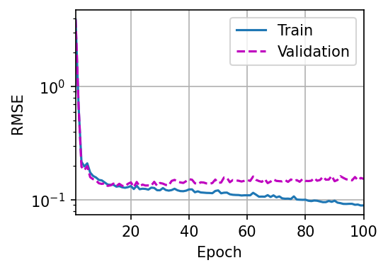

```python
# 设置超参数
k, num_epochs, learning_rate, weight_decay, batch_size = 5, 100, 0.01, 2, 64

# 训练
trainer = NetTrainer(train_features.shape[1])
avg_train_loss, avg_val_loss = trainer.k_fold_cross_validation(k, train_features, train_labels,
                                                               num_epochs, learning_rate, weight_decay, batch_size)

print(f'{k}-Fold Validation: Average Training Log RMSE: {float(avg_train_loss):.4f}, Average Validation Log RMSE: {float(avg_val_loss):.4f}')
```

当训练数据稀缺时，我们甚至可能无法提供足够的数据来构成一个合适的验证集。 这个问题的一个流行的解决方案是采用K折交叉验证。 这里，原始训练数据被分成K个不重叠的子集。 然后执行K次模型训练和验证，每次在K-1个子集上进行训练， 并在剩余的一个子集（在该轮中没有用于训练的子集）上进行验证。 最后，通过对K次实验的结果**取平均**来估计训练和验证误差。

```
Fold 1: Train loss = 0.1340, Validation loss = 0.1339
Fold 2: Train loss = 0.1278, Validation loss = 0.1573
Fold 3: Train loss = 0.1267, Validation loss = 0.1539
Fold 4: Train loss = 0.1306, Validation loss = 0.1377
Fold 5: Train loss = 0.1175, Validation loss = 0.1635
```

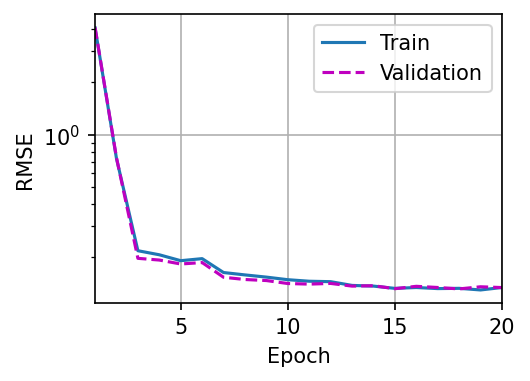

```python
num_epochs = 20
_, _ = trainer.k_fold_cross_validation(k, train_features, train_labels, 20, learning_rate, weight_decay, batch_size)
```

```
Training Log RMSE: 0.118953
```

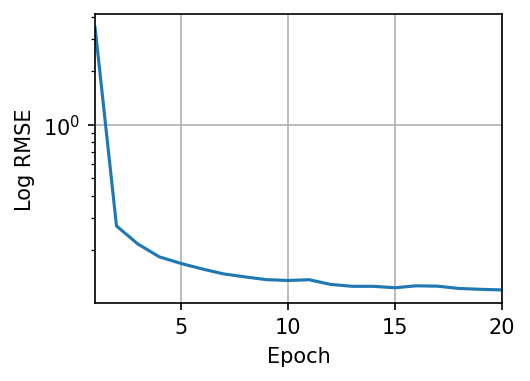

```python
trainer.train_and_predict(train_features, test_features, train_labels, test_data, num_epochs, learning_rate, weight_decay, batch_size)
```

[figure not shown]

排名：2083/4838

```
Fold 1: Train loss = 0.0896, Validation loss = 0.1452
Fold 2: Train loss = 0.0809, Validation loss = 0.1564
Fold 3: Train loss = 0.0850, Validation loss = 0.1538
Fold 4: Train loss = 0.0770, Validation loss = 0.1254
Fold 5: Train loss = 0.0784, Validation loss = 0.1692
5-Fold Validation: Average Training Log RMSE: 0.0822, Average Validation Log RMSE: 0.1500
```

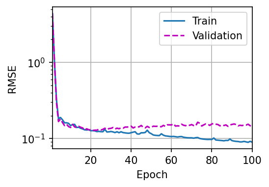

```python
# 设置超参数
num_epochs = 100

# 训练
trainer = NetTrainer(train_features.shape[1], hidden_sizes=[128, 64, 32])
avg_train_loss, avg_val_loss = trainer.k_fold_cross_validation(k, train_features, train_labels,
                                                               num_epochs, learning_rate, weight_decay, batch_size)

print(f'{k}-Fold Validation: Average Training Log RMSE: {float(avg_train_loss):.4f}, Average Validation Log RMSE: {float(avg_val_loss):.4f}')
```

```
Training Log RMSE: 0.079072
```

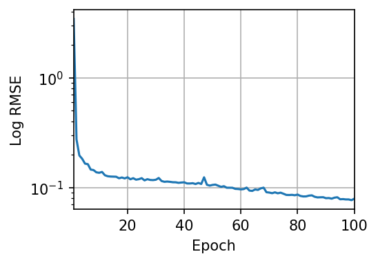

```python
trainer.train_and_predict(train_features, test_features, train_labels, test_data, num_epochs, learning_rate, weight_decay, batch_size)
```

训练更多步骤后再次测试，发现损失上升到0.15375，说明过拟合更加严重。

## 6. 文字总结最终的分析结果

我们使用了五折交叉验证对模型进行了评估。在整个训练过程中，平均训练 Log RMSE 为 0.0862，而平均验证 Log RMSE 为 0.1538。这表明我们的模型在训练集和验证集上均具有良好的拟合能力，验证误差高于训练误差，表明模型有轻微的过拟合。

在每个折叠中，训练和验证损失的变化趋势较为一致，这表明模型在不同数据集划分上的表现较为稳定。然而，在某些折叠中，我们观察到验证损失的波动较大，这可能是由于验证集上存在噪声数据或模型对某些特定特征的敏感性。

通过绘制训练和验证损失的曲线，我们发现：

- 在训练的早期阶段，损失迅速下降，这表明模型较快地学习到了数据的主要特征。
- 随着训练的进行，损失的下降趋势逐渐趋于平缓，这表明模型开始收敛。
- 在某些折叠中，验证损失在训练后期出现了轻微上升，这表明可能存在过拟合现象。

虽然模型在训练和验证集上的表现都较为理想，但验证集上的损失略高于训练集，提示我们模型有轻微的过拟合。这意味着模型能够很好地拟合训练数据，但在新的数据上表现稍逊。

将预测结果提交到kaggle，测得均方根误差为0.14198，与验证集误差相近，从排名上看属于中等。